# JACBT自主企画シンポジウム発表資料

~

2019-08-22

当日はリアルタイムに投稿可能なアプリケーションのURLを公開し、 そこでも意見を収集いたしいます。

### 「今すぐに取りいれたい学会運用のアイデア発表会」

#### 企画主旨

> 本シンポジウムでは、日本認知・行動療法学会に取り組んで頂きたいことについて、取り分け若手の目線からの具体的なアイデアを提案し、学会の運営に携わる先生方から提案されたアイデアの有用性やどのようなアクションが可能かなどについてコメントを頂くなかで、議論を深めていきたい。具体的には、竹林・谷口・横光の３名から、３つのテーマ（①学術研究の方向性について：学会が主導する重点的な臨床・研究テーマの実施など、②アカデミア以外との連携や広報の在り方について：企業や実践家と学会を連携させるシステム、現代的な広報の活用など、③若手の活躍の場について：若手間の研究協力の機会の増加や学術大会における若手企画など）に関するアイデアを提案し、その運営・維持の方法を解説する。なお、臨床に関する学会としての取り組みは十分であると判断し、本シンポジウムでは取り上げていない。そして、挙げられた案に対する有用性、及びそれらを実現するための方法等を鈴木先生・佐藤先生・岡島先生の３名からコメントをいただく。最後に、参加されている方々と意見交換をしながら、議論を深めていく。加えて、本シンポジウムでは、話題提供時に提案された案について、フロアでの意見（賛成～反対の５段階評価）を取るなどインタラクティブに進めていく予定である。

#### 話題提供

[竹林由武（福島県立医科大学）](https://ytake2.github.io/Rsite/_site/index.html)

[「認知・行動療法研究の価値を高める仕掛け」](https://ytake2.github.io/takeblog/post/img/takebayashi.pdf)

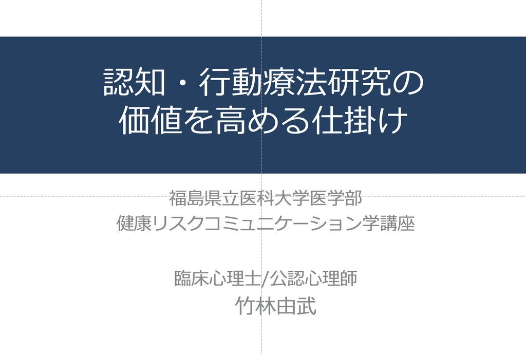

[谷口敏淳（一般社団法人Psychoro）](https://psychoro.org/)

[「アカデミアと臨床現場をつなぐプラットフォーム構築案」](https://ytake2.github.io/takeblog/post/img/taniguchi.pdf)

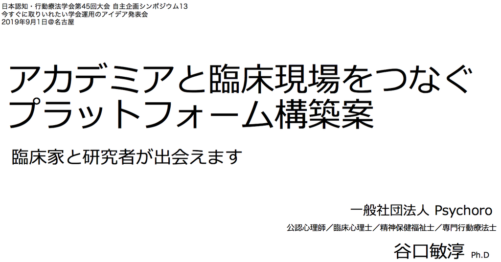

[横光健吾 （立命館大学）](https://psychoro.org/)

[「若手をより輝かせ、成長させる活躍の場」](https://ytake2.github.io/takeblog/post/img/yokomitsu.pdf)

[figure not shown]

#### コメンテーター

[佐藤 寛](http://psysci.kwansei.ac.jp/faculty/sato-hiroshi/)（関西学院大学）  
[鈴木伸一](http://www.f.waseda.jp/ssuzuki/)（早稲田大学）  
[岡島 義](https://behavioral-sleep-sciences-lab.jimdofree.com/) (東京家政大学)

よろしくお願いいたします。